# PGM3

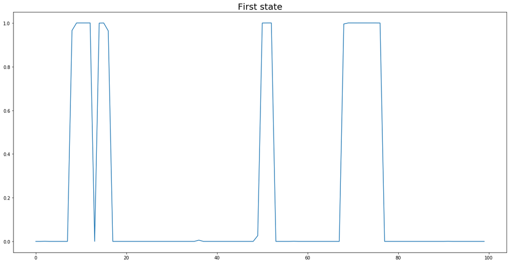

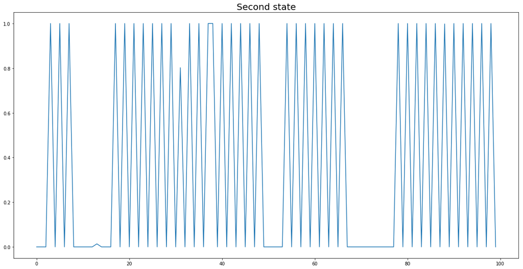

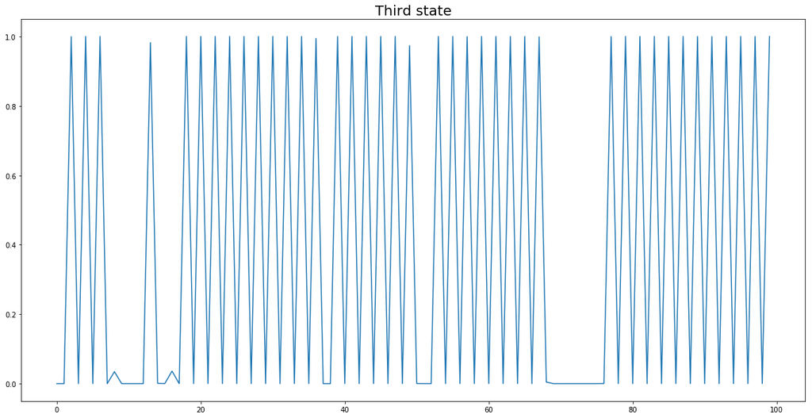

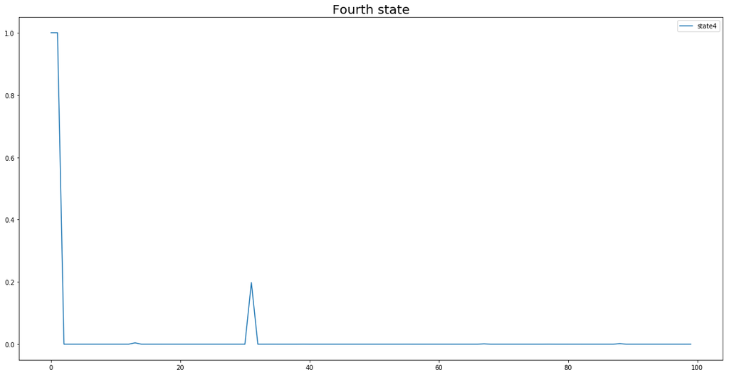

```python
time = np.arange(100)
plt.figure(1,figsize=(20,10))
plt.plot(state_1_test,label='state1')
plt.title('First state',fontsize = 20)
plt.figure(2,figsize=(20,10))
plt.plot(state_2_test,label='state2')
plt.title('Second state',fontsize = 20)
plt.figure(3,figsize=(20,10))
plt.plot(state_3_test,label='state3')
plt.title('Third state',fontsize = 20)
plt.figure(4,figsize=(20,10))
plt.plot(state_4_test,label='state4')
plt.title('Fourth state',fontsize = 20)
plt.legend()
plt.show()
```

10. For each of these same 100 points, compute their most likely state according to the marginal probability computed in the previous question. Make a plot representing the most likely state in {1,2,3,4} as function of time for these 100 points.

```python
most_likely_state_test_train = 1+np.argmax(marginals[:100],axis=1)
```

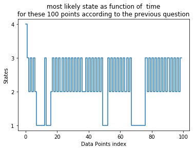

```python
plt.step(time,most_likely_state_test_train)
plt.xlabel('Data Points index')
plt.ylabel('States')
plt.title('most likely state as function of \
 time\nfor these 100 points according to the previous question')
plt.yticks([1,2,3,4])
plt.show()
```

11. Run Viterbi on the test data. Compare the most likely sequence of states obtained for the 100 first data points with the sequence of states obtained in the previous question. Make a similar plot. Comment.

```python
most_probable_sequence_test_100 = 1+most_likely_sequence_test[0][:100]
```

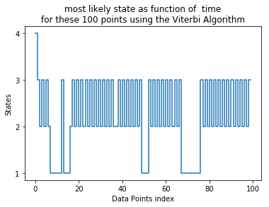

```python
plt.step(time,most_probable_sequence_test_100)
plt.xlabel('Data Points index')
plt.ylabel('States')
plt.title('most likely state as function of \
 time\nfor these 100 points using the Viterbi Algorithm')
plt.yticks([1,2,3,4])
plt.show()
```